# Course Project 1 - Reproducible Research

Tiago Assano

14/12/2018

```r
install.packages("dplyr", repos = 'http://cran.us.r-project.org')
library(dplyr)
```

## Introduction

It is now possible to collect a large amount of data about personal movement using activity monitoring devices such as a Fitbit, Nike Fuelband, or Jawbone Up. These type of devices are part of the ‘quantified self’ movement, a group of enthusiasts who take measurements about themselves regularly to improve their health, to find patterns in their behavior, or because they are tech geeks. But these data remain under-utilized both because the raw data are hard to obtain and there is a lack of statistical methods and software for processing and interpreting the data.

## Loading and preprocessing the data

This assignment makes use of data from a personal activity monitoring device. This device collects data at 5 minute intervals through out the day. The data consists of two months of data from an anonymous individual collected during the months of October and November, 2012 and include the number of steps taken in 5 minute intervals each day.

## Goal

The goal of this assignment is to understand the biases introduced by the “NA” values that exist in the database and if there are differences when we analyze data from weekdays and weekends.

## Data

The variables included in this dataset are:

- steps: Number of steps taking in a 5-minute interval (missing values are coded as NA)

- date: The date on which the measurement was taken in YYYY-MM-DD format
- interval: Identifier for the 5-minute interval in which measurement was taken

The dataset is stored in a comma-separated-value (CSV) file and there are a total of 17,568 observations in this dataset.

```r
file <- paste(getwd(), "/activity.csv", sep ="")
data <- read.csv(file)
```

This report is structuredn in a way that the proposed questions will be followed by the R code chunks used to analyze the data and by the printed results (either text or graphs).

Now proceeding to the assignemnt questions:

### What is mean total number of steps taken per day?

For this part of the assignment, you can ignore the missing values in the dataset.

1. Calculate the total number of steps taken per day.

Result:

```r
steps <- tapply(data$steps, data$date, sum)
steps
```

```
## 2012-10-01 2012-10-02 2012-10-03 2012-10-04 2012-10-05 2012-10-06
##         NA        126      11352      12116      13294      15420
## 2012-10-07 2012-10-08 2012-10-09 2012-10-10 2012-10-11 2012-10-12
##      11015         NA      12811       9900      10304      17382
## 2012-10-13 2012-10-14 2012-10-15 2012-10-16 2012-10-17 2012-10-18
##      12426      15098      10139      15084      13452      10056
## 2012-10-19 2012-10-20 2012-10-21 2012-10-22 2012-10-23 2012-10-24
##      11829      10395       8821      13460       8918       8355
## 2012-10-25 2012-10-26 2012-10-27 2012-10-28 2012-10-29 2012-10-30
##       2492       6778      10119      11458       5018       9819
## 2012-10-31 2012-11-01 2012-11-02 2012-11-03 2012-11-04 2012-11-05
##      15414         NA      10600      10571         NA      10439
## 2012-11-06 2012-11-07 2012-11-08 2012-11-09 2012-11-10 2012-11-11
##       8334      12883       3219         NA         NA      12608
## 2012-11-12 2012-11-13 2012-11-14 2012-11-15 2012-11-16 2012-11-17
##      10765       7336         NA         41       5441      14339
## 2012-11-18 2012-11-19 2012-11-20 2012-11-21 2012-11-22 2012-11-23
##      15110       8841       4472      12787      20427      21194
## 2012-11-24 2012-11-25 2012-11-26 2012-11-27 2012-11-28 2012-11-29
##      14478      11834      11162      13646      10183       7047
## 2012-11-30
##         NA
```

2. Make a histogram of the total number of steps taken each day

Result:

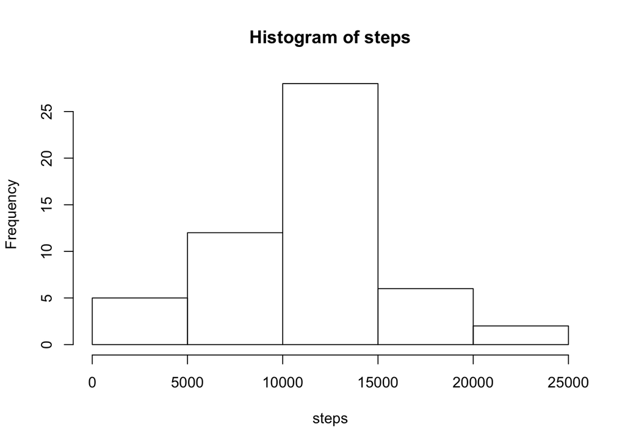

```r
hist(steps)
```

3. Calculate and report the mean and median of the total number of steps taken per day

Result:

mean

```r
mean(steps, na.rm= TRUE)
```

```
## [1] 10766.19
```

median

```r
median(steps, na.rm=TRUE)
```

```
## [1] 10765
```

### What is the average daily activity pattern?

1. Make a time series plot (i.e. type = “l”) of the 5-minute interval (x-axis) and the average number of steps taken, averaged across all days (y-axis)

Result:

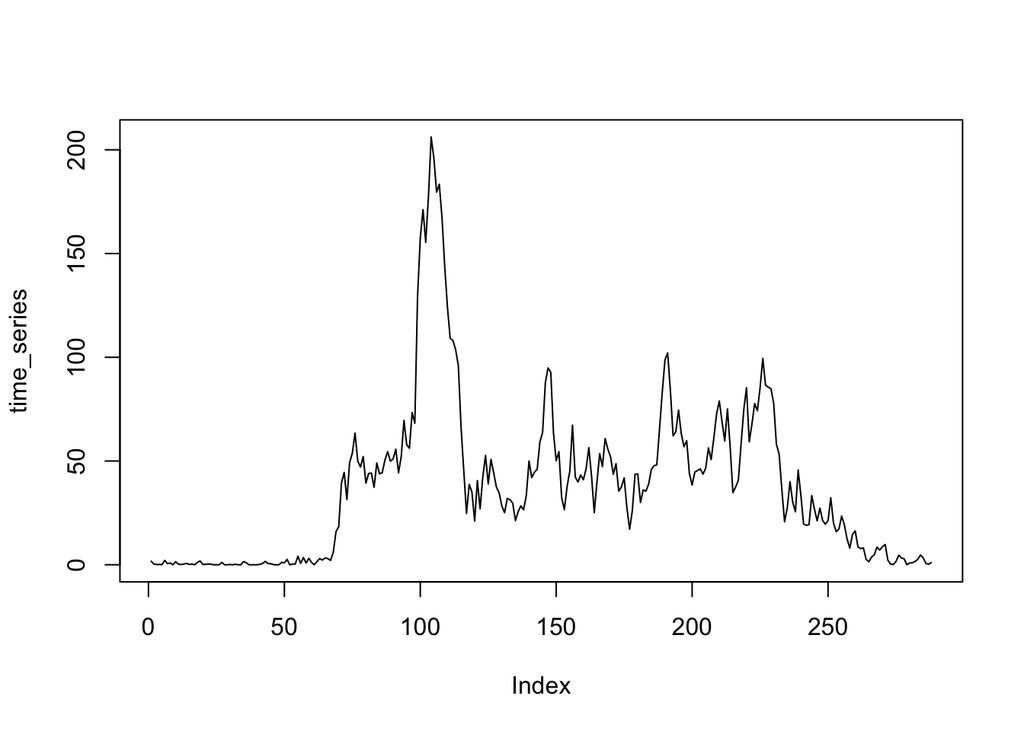

```r
data_clean = na.omit(data)
time_series <- tapply(data_clean$steps, data_clean$interval, mean)
plot(time_series, type="l")
```

2. Which 5-minute interval, on average across all the days in the dataset, contains more steps?

Result:

```r
time_series <- tapply(data_clean$steps, data_clean$interval, mean)
max <- which.max(time_series)
attributes(max)
```

```
## $names
## [1] "835"
```

### Imputing missing values

Note that there are a number of days/intervals where there are missing values (coded as NA). The presence of missing days may introduce bias into some calculations or summaries of the data.

1. Calculate and report the total number of missing values in the dataset (i.e. the total number of rows with NAs)

Result:

```r
length(which(is.na(data$steps)))
```

```
## [1] 2304
```

Devise a strategy for filling in all of the missing values in the dataset.

2. Create a new dataset that is equal to the original dataset but with the missing data filled in.

Result:

```r
head(data)
```

```
##   steps       date interval
## 1    NA 2012-10-01        0
## 2    NA 2012-10-01        5
## 3    NA 2012-10-01       10
## 4    NA 2012-10-01       15
## 5    NA 2012-10-01       20
## 6    NA 2012-10-01       25
```

```r
data_2 <-data
mean_steps <- mean(data$steps, na.rm = TRUE)
data_2 <- data_2 %>% replace(., is.na(.), mean_steps)
head(data_2)
```

```
##     steps       date interval
## 1 37.3826 2012-10-01        0
## 2 37.3826 2012-10-01        5
## 3 37.3826 2012-10-01       10
## 4 37.3826 2012-10-01       15
## 5 37.3826 2012-10-01       20
## 6 37.3826 2012-10-01       25
```

Result:

```r
steps_2 <- tapply(data_2$steps, data_2$date, sum)
steps_2
```

```
## 2012-10-01 2012-10-02 2012-10-03 2012-10-04 2012-10-05 2012-10-06
##   10766.19     126.00   11352.00   12116.00   13294.00   15420.00
## 2012-10-07 2012-10-08 2012-10-09 2012-10-10 2012-10-11 2012-10-12
##   11015.00   10766.19   12811.00    9900.00   10304.00   17382.00
## 2012-10-13 2012-10-14 2012-10-15 2012-10-16 2012-10-17 2012-10-18
##   12426.00   15098.00   10139.00   15084.00   13452.00   10056.00
## 2012-10-19 2012-10-20 2012-10-21 2012-10-22 2012-10-23 2012-10-24
##   11829.00   10395.00    8821.00   13460.00    8918.00    8355.00
## 2012-10-25 2012-10-26 2012-10-27 2012-10-28 2012-10-29 2012-10-30
##    2492.00    6778.00   10119.00   11458.00    5018.00    9819.00
## 2012-10-31 2012-11-01 2012-11-02 2012-11-03 2012-11-04 2012-11-05
##   15414.00   10766.19   10600.00   10571.00   10766.19   10439.00
## 2012-11-06 2012-11-07 2012-11-08 2012-11-09 2012-11-10 2012-11-11
##    8334.00   12883.00    3219.00   10766.19   10766.19   12608.00
## 2012-11-12 2012-11-13 2012-11-14 2012-11-15 2012-11-16 2012-11-17
##   10765.00    7336.00   10766.19      41.00    5441.00   14339.00
## 2012-11-18 2012-11-19 2012-11-20 2012-11-21 2012-11-22 2012-11-23
##   15110.00    8841.00    4472.00   12787.00   20427.00   21194.00
## 2012-11-24 2012-11-25 2012-11-26 2012-11-27 2012-11-28 2012-11-29
##   14478.00   11834.00   11162.00   13646.00   10183.00    7047.00
## 2012-11-30
##   10766.19
```

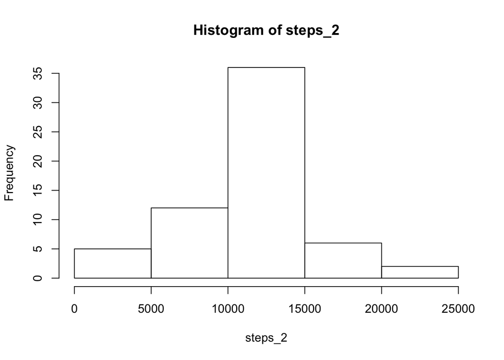

```r
hist(steps_2)
```

Mean

```r
mean(steps_2)
```

```
## [1] 10766.19
```

Median

```r
median(steps_2)
```

```
## [1] 10766.19
```

### Are there differences in activity patterns between weekdays and weekends?

Create a new factor variable in the dataset with two levels – “weekday” and “weekend” indicating whether a given date is a weekday or weekend day.

Result:

```r
data_2$date <- as.Date(data_2$date)
weekname <- weekdays(as.Date(data_2$date))
data_2_wkd <- cbind(data_2, weekname)
days <- ifelse( data_2_wkd$weekname %in% c("Sábado", "Domingo"), "weekend", "weekday")
data_2_wkd <- cbind(data_2_wkd, days)
```

Result:

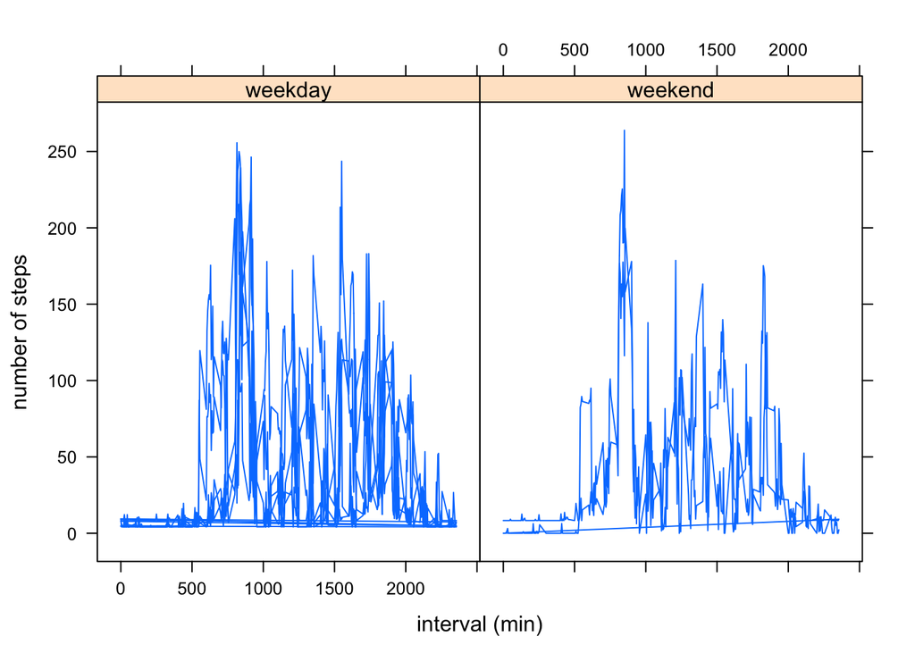

```r
library("lattice")
xyplot( tapply(X= data_2_wkd$steps, INDEX = list(data_2_wkd$interval, data_2_wkd$weekname), mean) ~ interval  | days, data = data_2_wkd, type = "l", ylab = "number of steps", xlab = "interval (min)")
```